# Assignment 01

S.K. Krueger

2021-08-24

First, I made a ggplot to show the mass (g) and reproductive condition of individual bats caught on Fort Campbell Army Installation from 2020-2021.

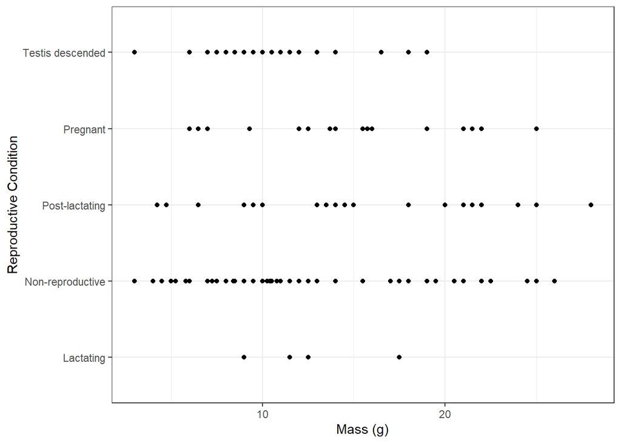

```r
bat.morph <- read.csv(file.choose())

model_1 <- ggplot(bat.morph, aes(Mass, Reproductive.Condition)) +
  geom_point() +
  xlab("Mass (g)") +
  ylab("Reproductive Condition") +
  theme_bw()

model_1
```

Second, I made a ggplot to show differences in mass(g) with reproductive and non-reproductive female bats.

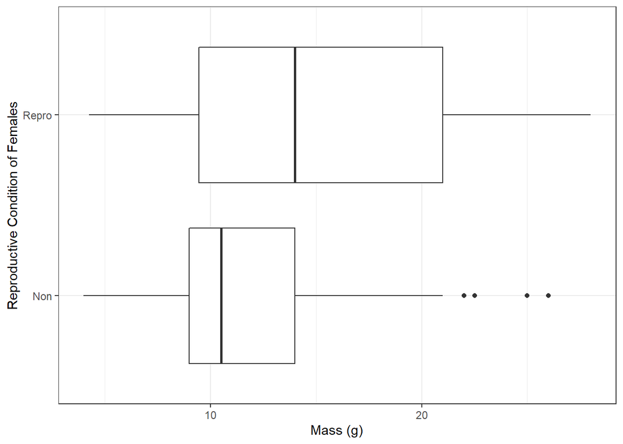

```r
bat.morph <- read.csv(file.choose())

females.only <- bat.morph[bat.morph$Sex == "Female"& bat.morph$Reproductive.Condition != "Unknown",]

females.only$Repro <- ifelse(females.only$Reproductive.Condition == "Non-reproductive",
                             "Non",
                             "Repro")


model_2 <- ggplot(females.only, aes(Mass, Repro)) +
           geom_boxplot() +
           xlab("Mass (g)") +
           ylab("Reproductive Condition of Females") +
           theme_bw()
model_2
```

Next, I fit a linear model and ran an anova on forearm (mm) length.

```r
bat.morph <- read.csv(file.choose())

lm.Pesu <- lm(Mass ~ Forearm_mm, data = bat.morph[bat.morph$Species == "Perimyotis subflavus", ])

summary(lm.Pesu)
```

```
##
## Call:
## lm(formula = Mass ~ Forearm_mm, data = bat.morph[bat.morph$Species ==
##     "Perimyotis subflavus", ])
##
## Residuals:
##     Min      1Q  Median      3Q     Max
## -2.6237 -1.2152 -0.4022  1.0303  3.8037
##
## Coefficients:
##             Estimate Std. Error t value Pr(>|t|)
## (Intercept)  8.16842    5.78819   1.411    0.172
## Forearm_mm  -0.07723    0.17291  -0.447    0.660
##
## Residual standard error: 1.638 on 22 degrees of freedom
## Multiple R-squared:  0.008986,   Adjusted R-squared:  -0.03606
## F-statistic: 0.1995 on 1 and 22 DF,  p-value: 0.6595
```

```r
anova(lm.Pesu)
```

|  | Df | Sum Sq | Mean Sq | F value | Pr(>F) |
| --- | --- | --- | --- | --- | --- |
| Forearm_mm | 1 | 0.5355391 | 0.5355391 | 0.1994873 | 0.6595007 |
| Residuals | 22 | 59.0607109 | 2.6845778 | NA | NA |

For one of my tables, I summarized the mass (g) of all bats caught on Fort Campbell from 2020-2021.

```r
bat.morph <- read.csv(file.choose())

bat.morph <- bat.morph[bat.morph$Sex != "Unknown",]

summary1 <- summarise(group_by(bat.morph, Sex),
          n=n(),
          mean=mean(Mass),
          sd=sd(Mass))

kable(summary1, format = "pandoc", caption = 'Table 1. A summary table displaying number, mean, and standard deviation for the mass (g) of all bats.')
```

Table 1. A summary table displaying number, mean, and standard deviation for the mass (g) of all bats.

| Sex | n | mean | sd |
| --- | --- | --- | --- |
| Female | 105 | 13.15381 | 5.89717 |
| Male | 151 | 10.20199 | 2.89690 |

For my second table, I summarized the forearm (mm) of all bats caught on Fort Campbell from 2020-2021.

```r
bat.morph <- read.csv(file.choose())

bat.morph <- bat.morph[bat.morph$Sex != "Unknown",]

summary1 <- summarise(group_by(bat.morph, Sex),
          n=n(),
          mean=mean(Forearm_mm),
          sd=sd(Forearm_mm))

kable(summary1, format = "pandoc", caption = 'Table 2. A summary table displaying number, mean, and standard deviation for the forearm length (mm) of all bats.')
```

Table 2. A summary table displaying number, mean, and standard deviation for the forearm length (mm) of all bats.

| Sex | n | mean | sd |
| --- | --- | --- | --- |
| Female | 105 | 41.22667 | 5.226086 |
| Male | 151 | 39.06192 | 3.932013 |

Here is an example of a location where we captured a pregnant Tri-colored bat.

```r
sites <- read.csv(file.choose())

leaflet() %>%
  setView(-87.51230, 36.57480, zoom = 16) %>% #lat-long of the place of interest
  addTiles() %>%
  addMarkers(-87.51230, 36.57480, popup = "Site 62A")
```

[interactive chart not shown]

More information regarding our current bat research in collaboration with Fort Campbell Fish and Wildlife can be found [here](https://www.army.mil/article/238167/intergovernmental_support_agreement_fort_campbell_partners_with_local_university_to_track_endangered_bat_species).